# Act_Report

## Act Report

**This act report is the summary of the data analyst process carried out on the wrangling project including insights drawn and the visualisations used**

I worked with three datasets on this project:

- The first dataset, a csv file named `twitter_archive_enhanced.csv`, was provided by Udacity. It contains basic information about 2356 tweets and was downloaded manually.
- The second dataset was a tsv file named `image_prediction.tsv`; this dataset was hosted on udacity server and was downloaded programmatically. It contains 2075 predictions made using a neural network that can classify dog breeds.
- The third dataset, I scrapped the twitter API using python Tweepy’s Library. This third dataset was to get some information like the rewetet count and favorite countwhich were not available in the first dataset provided. These records were saved in a `tweet_json.txt` file and contains 2327 rows

I assessed the datasets both visually and programmatically and found 8 quality issues and 3 tidiness issues. I used a variety of Pandas methods to clean them up and then merged the three datasets into one named `twitter_archive_master.csv`; further cleaned this combined dataset and carried out some `analyses` and `visualisations` which arrived at some insights as discussed below:

The cleaned dataset was analyzed under the following headings:

1. Which dog stage do people like more: Which stage recieved the highest likes and retweets
2. Which dog stage recieved the most and highest rating?
3. What is the correlation between retweet count and favorites count

A plot between the retweets count and the favorites count were made against each dog stage to find out which dog stage recieved more likes and retweeted the most. This would be an indication of the stage that people liked more. The chart is represented below:

[figure not shown]

[figure not shown]

Also, A plot between the number of ratings and highest ratings were made against each dog stage to find out which dog stage was rated the most and highest. This would be a confirmation of the dog stage that people liked more. The chart is represented below:

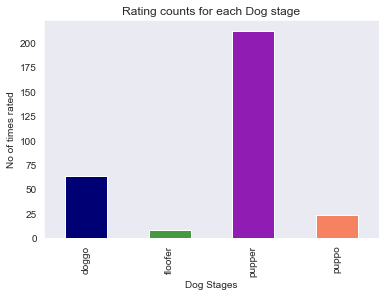

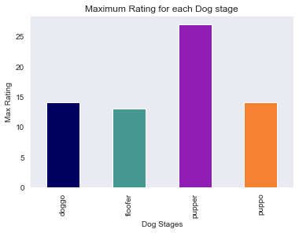

**From the above, more people rated the pupper dog stage. It also recieved the highest rating concluding our initial theory that people preferred that dog stage**

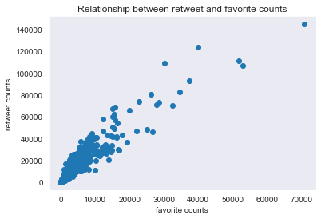

From the chart, it was found that there exists a stromg positive correlation between retweet count and favorites count.